# VADER Sentiment Analysis of Bitcointalk Topics

## Negative Sentiment WordCloud

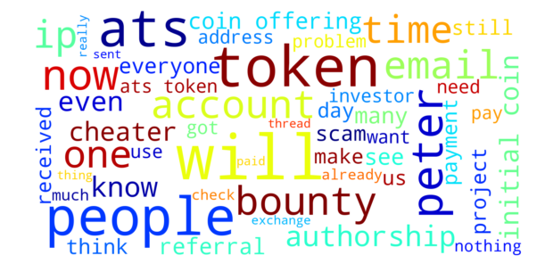

```python
stopwords = set(STOPWORDS)
wordcloud = WordCloud(
    background_color='white',
    stopwords=stopwords,
    width=1600,
    height=800,
    random_state=21,
    colormap='jet',
    max_words=50,
    max_font_size=200).generate(negResults)
plt.figure(figsize=(10, 10))
plt.imshow(wordcloud, interpolation='bilinear')
plt.axis("off")
plt.show()
```

## Positive Sentiment WordCloud

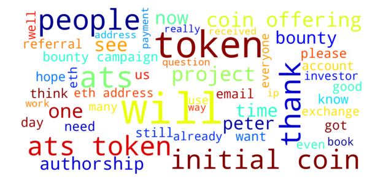

```python
stopwords = set(STOPWORDS)
wordcloud = WordCloud(
    background_color='white',
    stopwords=stopwords,
    width=1600,
    height=800,
    random_state=21,
    colormap='jet',
    max_words=50,
    max_font_size=200).generate(posResults)
plt.figure(figsize=(10, 10))
plt.imshow(wordcloud, interpolation='bilinear')
plt.axis("off")
plt.show()
```

## Neutral Sentiment WordCloud

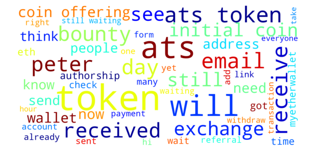

```python
stopwords = set(STOPWORDS)
wordcloud = WordCloud(
    background_color='white',
    stopwords=stopwords,
    width=1600,
    height=800,
    random_state=21,
    colormap='jet',
    max_words=50,
    max_font_size=200).generate(neuResults)
plt.figure(figsize=(10, 10))
plt.imshow(wordcloud, interpolation='bilinear')
plt.axis("off")
plt.show()
```

```python
data = pd.read_csv(inputCsvName)
data['Time'] = pd.to_datetime(data.Time)
#data.head()
```

```python
def assessments(str):
    blob = TextBlob(str)
    return blob.sentiment_assessments.assessments


def translated(series):
    blob = TextBlob(series)
    try:
        trans = blob.translate(to='en')
        return trans.raw
    except textblob.exceptions.NotTranslated:
        return ''


data['Blob'] = data.Body.apply(TextBlob)
data['Polarity'] = data.Blob.apply(attrgetter('sentiment.polarity'))
data['Subjectivity'] = data.Blob.apply(attrgetter('sentiment.subjectivity'))
data['Assessment'] = data.Body.apply(assessments)
# data['Detect_lang'] = data.Blob.apply(
#     methodcaller('detect_language'))  # powered by google API
# data['Translated'] = data.Body.apply(translated)
data['Vader_sentiment'] = data.Body.apply(Analyzer.polarity_scores)
data['Vader_compound'] = data['Vader_sentiment'].apply(lambda x: x['compound'])
```

## Topic's Post Compared using VADER and Textblob Sentiment

```python
data[['Body', 'Polarity', 'Subjectivity', 'Vader_compound', 'Vader_sentiment']]
```

|  | Body | Polarity | Subjectivity | Vader_compound | Vader_sentiment |
| --- | --- | --- | --- | --- | --- |
| 0 | I really hope that ATS goes to the exchangers very soon. Then all of the whiners can sell of their coins below $0.15 while others and myself buy at dirt cheap prices. | 0.266667 | 0.400000 | 0.0498 | {'neg': 0.114, 'neu': 0.796, 'pos': 0.091, 'compound': 0.0498} |
| 1 | I signed up once and shared my link on Reddit and haven't received any tokens.. My withdrawal was even confirmed via email.. | 0.400000 | 1.000000 | 0.3612 | {'neg': 0.0, 'neu': 0.844, 'pos': 0.156, 'compound': 0.3612} |
| 2 | AUTHORSHIP is Scam 8158 people sent a fake number 45 days withdraw ? Thousand people waitting recive ATS token but they has officially ended. This is peterauthorship post on forum [/quote] We'll pay e… | -0.258333 | 0.637500 | -0.9851 | {'neg': 0.302, 'neu': 0.675, 'pos': 0.023, 'compound': -0.9851} |
| 3 | This was by definition not a sweepstakes and "bounty campaigns" are not regulated by the FTC. Good luck with your lawsuits, buddy. | 0.700000 | 0.600000 | 0.6486 | {'neg': 0.063, 'neu': 0.706, 'pos': 0.231, 'compound': 0.6486} |
| 4 | I registered one time only and i received nothing, never saw so much incompetence, this is shady, good i did not invest in this terrible dev team!!!! | -0.070000 | 0.685000 | -0.7559 | {'neg': 0.259, 'neu': 0.651, 'pos': 0.09, 'compound': -0.7559} |
| ... | ... | ... | ... | ... | ... |
| 3573 | Update: VIDEO with our CEO N. Warfield offering an overview of the upcoming Authorship.com platform: http://authorship.com/2017/08/09/video-ceo-n-warfield-offers-an-overview-about-the-upcoming-authors… | 1.000000 | 0.300000 | 0.6369 | {'neg': 0.0, 'neu': 0.802, 'pos': 0.198, 'compound': 0.6369} |
| 3574 | Very interesting project. Is there any bounty campaign? | 0.650000 | 0.650000 | 0.4576 | {'neg': 0.0, 'neu': 0.7, 'pos': 0.3, 'compound': 0.4576} |
| 3575 | Hi, while we don't have an official bounty campaign, we are happy to pay, upfront, for any marketing offers that could benefit us. Feel free to send me a PM with more details. The invitation is open t… | 0.360000 | 0.560000 | 0.9022 | {'neg': 0.028, 'neu': 0.721, 'pos': 0.251, 'compound': 0.9022} |
| 3576 | Update: Twitter campaign is open for interested participants: https://bitcointalk.org/index.php?topic=2080397.0 Thank you, Peter | 0.125000 | 0.500000 | 0.6369 | {'neg': 0.0, 'neu': 0.658, 'pos': 0.342, 'compound': 0.6369} |
| 3577 | Good luck Peter.. I really like content based projects and look forward to seeing more of them. | 0.466667 | 0.433333 | 0.8268 | {'neg': 0.0, 'neu': 0.599, 'pos': 0.401, 'compound': 0.8268} |

3578 rows × 5 columns

# Is this Cryptocurrency a Scam?

Based on reports leading to acknowledgement of a scam possibility, combined with the sentiment analysis results, a plausible determination can be shown. *NOTE*: These results should not be taken as fact, but rather as an aide to determine the possibility that a particular cryptocurrency could be showing signs of a scam attempt.

```python
isScamHeader = False
count = 0
scamCount = 0
scam = 'Very Unlikely'
ratio = (neg / (pos + neg + neu)) * 100

print('Analysis for: ', row[12])
for word in common_words2:
    count+=1
    if word[0] == 'scam':
        print('Count of the word Scam: ', word[1])
        print('Word use ranked at: ', count)
        scamCount = count
if row[14] == 'True':
    isScamHeader = True
if((20 > ratio >= 10) and isScamHeader == False):
    scam = 'Unlikely'
if((35 > ratio >= 20) and isScamHeader == False):
    scam = 'Possible'
if((ratio >= 35) and isScamHeader == False and (scamCount == 0)):
    scam = 'Possible'
if((ratio >= 35) and isScamHeader == False and (0 < scamCount < 10)):
    scam = 'Likely'
if((20 > ratio >= 10) and isScamHeader == True):
    scam = 'Possible'
if((33 > ratio >= 20) and isScamHeader == True and (0 < scamCount <= 30)):
    scam = 'Likely'
if((50 > ratio >= 33) and isScamHeader == True and (0 < scamCount <= 20)):
    scam = 'Very Likely'
if((ratio >= 50) and isScamHeader == True and (0 < scamCount < 10)):
    scam = 'Almost Certain'

print('Negative Sentiment in topic: ~', round(ratio), '%')
print('Likelihood of scam: \033[1m' + scam)
if(isScamHeader == True):
    print('This Cryptocurrency has been reported as a potential scam attempt')
print('\033[0m')
```

```
Analysis for:  [ANN][ICO] Authorship - Making the Internet More Free and Accessible For Authors
Count of the word Scam:  121
Word use ranked at:  9
Negative Sentiment in topic: ~ 20 %
Likelihood of scam: Possible
This Cryptocurrency has been reported as a potential scam attempt
```

## Explanation of Results

The likelihood of the cryptocurrency being a scam is based on several characteristics sorted into categories:

- **Very Unlikely**: Shows minimal negativity, not reported as scam, low use of the word *scam*
- **Unlikely**: Shows low negativity, not reported as scam, low use of the word *scam*
- **Possible**: Shows moderative negativity, moderate use of the word *scam* and may have been reported
- **Likely**: Shows above normal negativity, above normal use of the word *scam* and may have been reported
- **Very Likely**: Shows above normal negativity, above normal use of the word *scam* and was reported
- **Almost Certain**: Shows high negativity, high usage of the word scam and was reported as *scam*

The results of this analysis are shown above this explanation and mention the likelihood along with a note if the scam was reported on Bitcointalk.org as showing signs of a scam attempt. These results show the word count of *scam* and its ranking compared to other words in the forum topic. Based on the increasing negativity, the ranking of the usage of *scam* in comparison to other word choices and the potential reporting of a scam, this analysis places emphasis on a building negativity relative to other posts and ranks the likelihood accordingly.

```python
#os.system('jupyter nbconvert --to html vaderSentAnalysis.ipynb') # Output without custom filename
os.system('jupyter nbconvert --to html vaderSentAnalysis.ipynb --output-dir ./data/processed --output ' + csvName + '.html')
os.system('jupyter nbconvert --to markdown vaderSentAnalysis.ipynb --output-dir ./data/processed --output ' + csvName + '.md')
os.system('jupyter nbconvert --to pdf vaderSentAnalysis.ipynb --output-dir ./data/processed --output ' + csvName + '.pdf')
```

```
0
```